# Imaging QC

## Normalization via housekeeping genes

Here we normalize by housekeeping genes. First we have to pick which housekeeping genes to use to normalize. We will pick housekeeping genes that have an expression level much higher than the noise floor and are not highly variably across the samples to do the normalization. We’ll select genes that are 4x higher than the limit of detection in all samples.

```r
> library(matrixStats)
> hk = ncounts[grepl("Housekeeping", rownames(ncounts)), ]
> abovenoise = rowSums(hk > (4 * lod)) == ncol(hk)
> hk = hk[abovenoise, ]
```

We’ll also pick genes that have a CV on the lower end. We’ll set a cutoff of the mean + 2 SD.

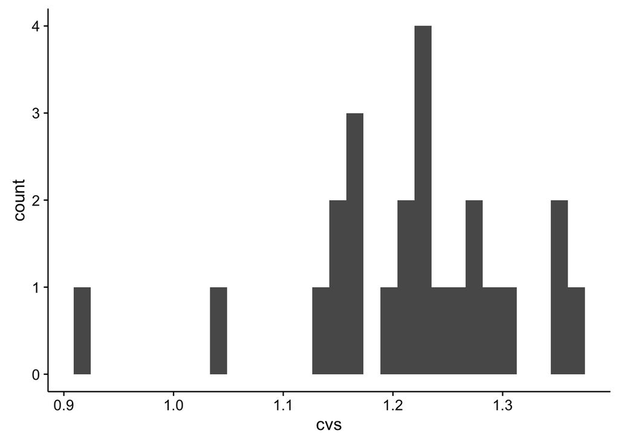

```r
> cvs = rowMeans(hk)/rowSds(hk)
> qplot(cvs) + geom_histogram()
```

```r
> hk = hk[cvs < (mean(cvs) + 2 * sd(cvs)), ]
> hk_norm = rownames(hk)
```

That leaves us with 24 genes to use to normalize the samples.

Normalizing by housekeeping genes does a good job making the samples more similar to each other.

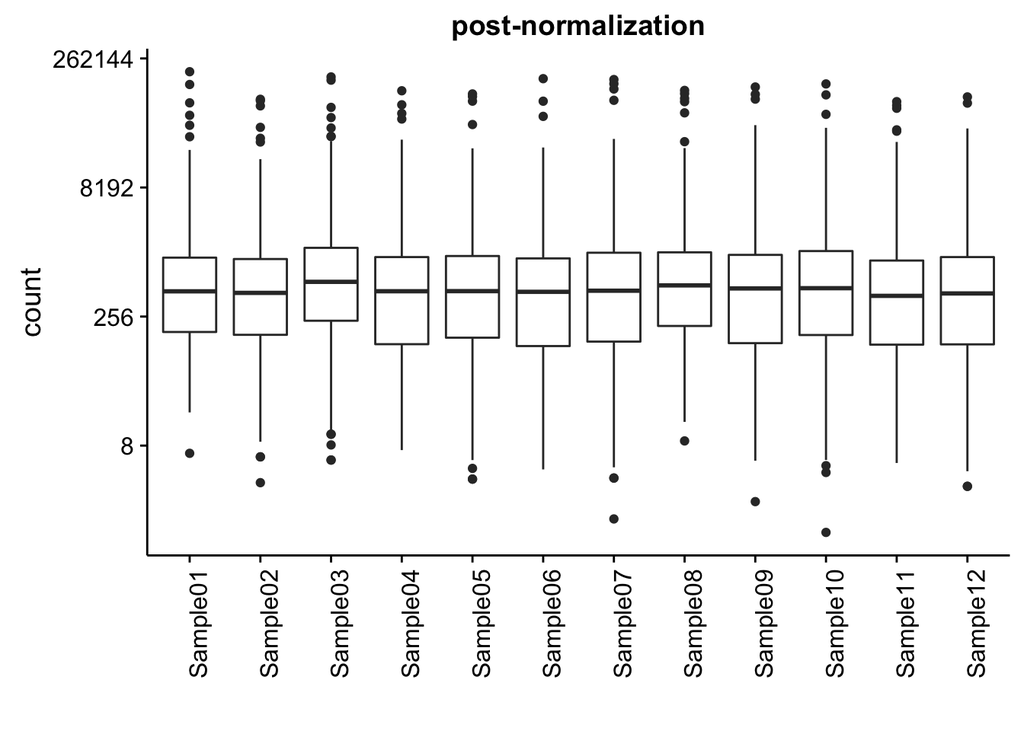

```r
> hk_pos = function(counts) {
+     hk = counts[hk_norm, ]
+     geoMeans = apply(hk, 2, function(col) exp(mean(log(col[col != 0]))))
+     return(geoMeans)
+ }
> hkFactor = function(counts) {
+     geoMeans = hk_pos(counts)
+     nf = mean(geoMeans)/geoMeans
+     return(nf)
+ }
> metadata$hk_nf = hkFactor(ncounts)
> ncounts = ncounts %*% diag(metadata$hk_nf)
> colnames(ncounts) = colnames(counts)
> postnorm = ncounts %>% data.frame() %>% tidyr::gather("sample", "count")
> ggplot(postnorm, aes(sample, count)) + geom_boxplot() + scale_y_continuous(trans = log2_trans()) +
+     xlab("") + ggtitle("post-normalization") + theme(axis.text.x = element_text(angle = 90,
+     hjust = 1))
```

# Normalization factor vs binding density

We can see the binding density is negatively correlated to the amount of positive control present. When there is less RNA in the cartridge, more of what is sequences is the positive controls.

We see the binding density is positive correlated to the housekeeping genes. If there is less RNA in the samples we should see less of the housekeeping genes.

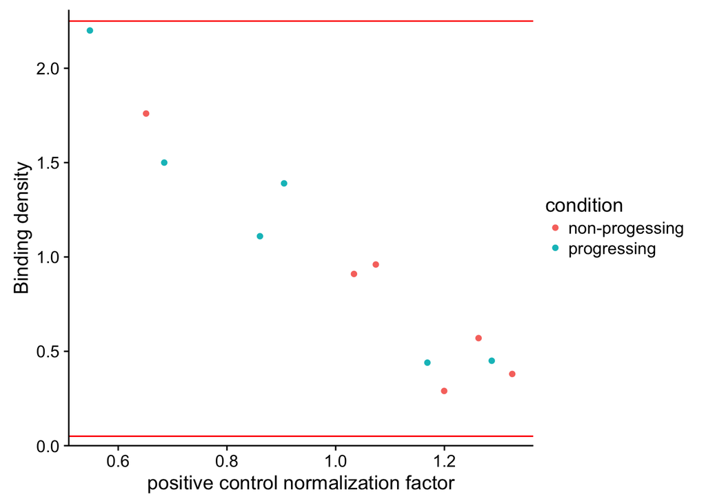

```r
> plotBD = function(eset, metadata) {
+     pdat = pData(eset) %>% tibble::rownames_to_column() %>% left_join(metadata,
+         by = c(rowname = "sample"))
+     pdat$pcounted = pdat$FovCounted/pdat$FovCount * 100
+     ggplot(pdat, aes(1/pos_nf, BindingDensity, color = condition)) + geom_point() +
+         scale_y_continuous(expand = c(0, 0)) + expand_limits(y = c(0, 1.05 *
+         max(pdat$BindingDensity))) + ylab("Binding density") + xlab("positive control normalization factor") +
+         geom_hline(yintercept = 0.05, color = "red") + geom_hline(yintercept = 2.25,
+         color = "red")
+ }
> plotBD(eset, metadata)
```

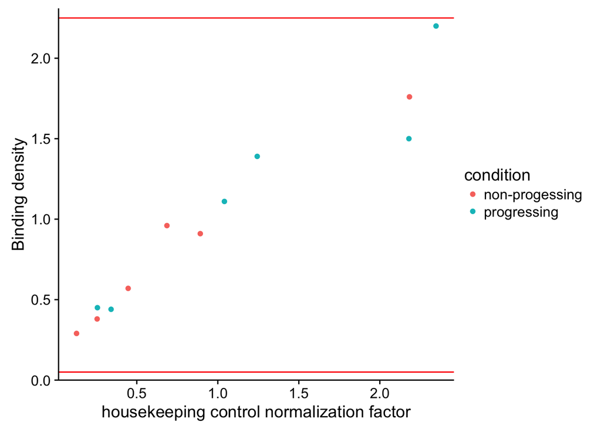

```r
> plotBD = function(eset, metadata) {
+     pdat = pData(eset) %>% tibble::rownames_to_column() %>% left_join(metadata,
+         by = c(rowname = "sample"))
+     pdat$pcounted = pdat$FovCounted/pdat$FovCount * 100
+     ggplot(pdat, aes(1/hk_nf, BindingDensity, color = condition)) + geom_point() +
+         scale_y_continuous(expand = c(0, 0)) + expand_limits(y = c(0, 1.05 *
+         max(pdat$BindingDensity))) + ylab("Binding density") + xlab("housekeeping control normalization factor") +
+         geom_hline(yintercept = 0.05, color = "red") + geom_hline(yintercept = 2.25,
+         color = "red")
+ }
> plotBD(eset, metadata)
```

# Drop genes

```r
> drop_unusable = function(counts) {
+     drop = is_spikein(rownames(counts))
+     drop = drop | is_positive(rownames(counts))
+     drop = drop | is_housekeeping(rownames(counts))
+     drop = drop | is_ligation(rownames(counts))
+     drop = drop | is_negative(rownames(counts))
+     keep = counts[!drop, ]
+     keep = keep[, !grepl("Blank", colnames(keep))]
+     return(keep)
+ }
> ncounts = drop_unusable(ncounts)
> ncounts = ncounts[(rowSums(ncounts < lod) < (0.2 * ncol(ncounts))), ]
> ncounts = round(ncounts)
```

We’re left with 658 genes to work with.

# Sample clustering

```r
> library(edgeR)
> library(limma)
> library(vsn)
> design = model.matrix(~condition, data = metadata)
```

Here we scaled and centered the normalized data and then performed PCA to look at how the samples cluster. The samples don’t cluster clearly along components 1-4 by condition, which indicates the samples are more variable than the signal between the progressing/non-progressinfg samples, if the signal exists.

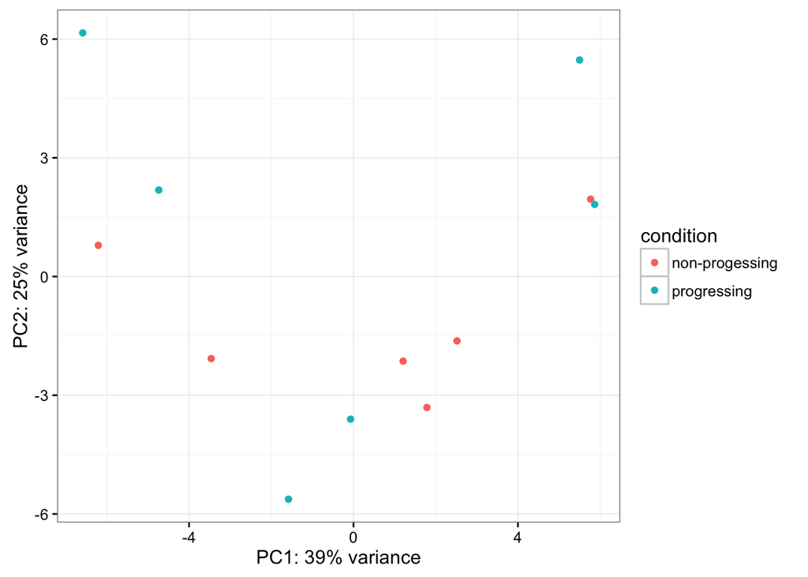

```r
> pca_loadings = function(object, ntop = 500) {
+     object = as.matrix(object)
+     rv <- matrixStats::rowVars(object)
+     select <- order(rv, decreasing = TRUE)[seq_len(min(ntop, length(rv)))]
+     pca <- prcomp(t(object[select, ]))
+     percentVar <- pca$sdev^2/sum(pca$sdev^2)
+     names(percentVar) = colnames(pca$x)
+     pca$percentVar = percentVar
+     return(pca)
+ }
> pcdata = scale(ncounts, center = TRUE, scale = TRUE)
> pc = pca_loadings(pcdata, 50)
> comps = data.frame(pc$x)
> comps$Name = rownames(comps)
> library(dplyr)
> comps = comps %>% left_join(metadata, by = c(Name = "sample"))
> pca_plot = function(comps, nc1, nc2, colorby) {
+     c1str = paste0("PC", nc1)
+     c2str = paste0("PC", nc2)
+     ggplot(comps, aes_string(c1str, c2str, color = colorby)) + geom_point() +
+         theme_bw() + xlab(paste0(c1str, ": ", round(pc$percentVar[nc1] * 100),
+         "% variance")) + ylab(paste0(c2str, ": ", round(pc$percentVar[nc2] *
+         100), "% variance"))
+ }
> pca_plot(comps, 1, 2, "condition")
```

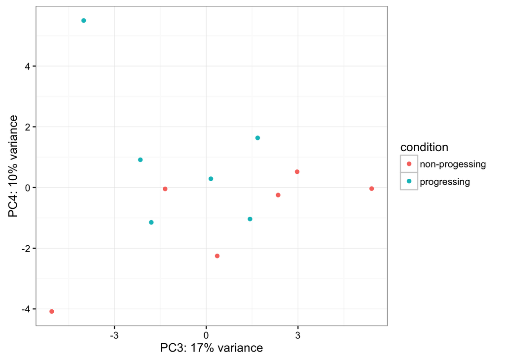

```r
> pca_plot(comps, 3, 4, "condition")
```

# Differential expression

## DESeq2

Here, we skip the internal DESeq2 normalization step since we have normalized the counts already.

```r
> library(DESeq2)
> design = ~condition
> dds = DESeqDataSetFromMatrix(countData = ncounts, colData = metadata, design = design)
> sizeFactors(dds) = rep(1, ncol(ncounts))
> dds = DESeq(dds)
> res = results(dds, addMLE = TRUE) %>% data.frame() %>% tibble::rownames_to_column() %>%
+     arrange(pvalue)
> write_csv(res, "deseq2.csv")
```

We aren’t seeing too much signal between the groups, we don’t find much different between the samples. That doesn’t mean the data is unusable, but it means to go any further with it you’d have to use the list as a way to narrow down what might be changing, and confirm it via a different method.

## T-test

The nSolver analysis suite from NanoString just uses a t-test to test the differences rather than fit a negative binomial model. Doing that we also don’t see any differences. We can see the two methods are strongly correlated if we plot the p-values against each other.

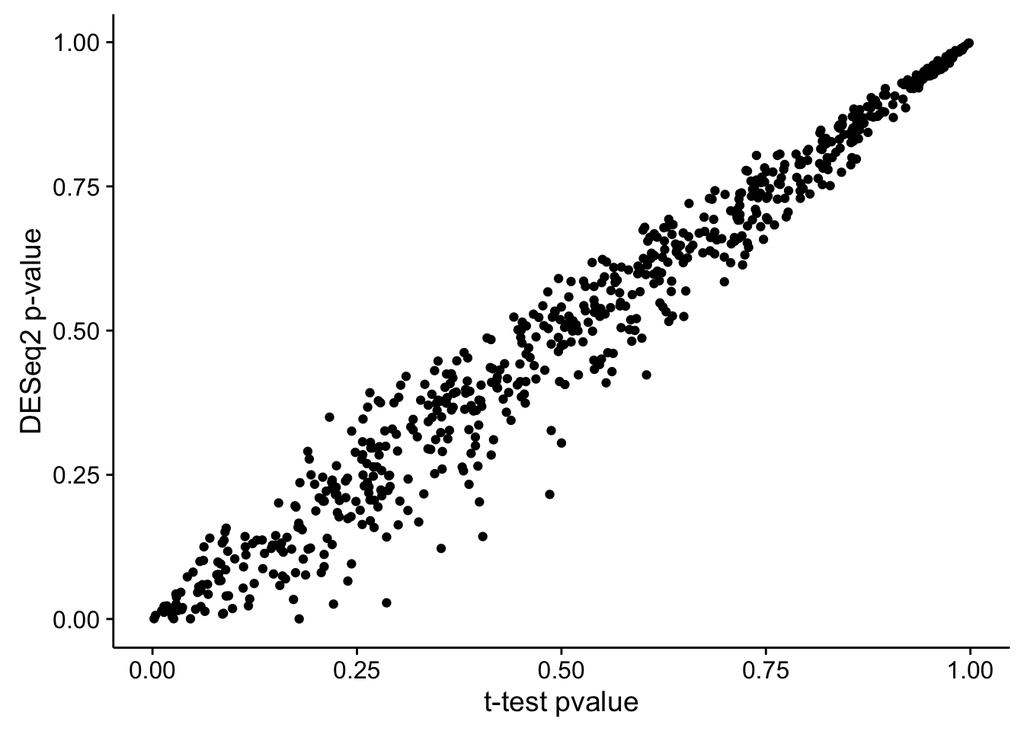

```r
> t_results = apply(ncounts, 1, function(x) t.test(x[1:6], x[7:12]))
> pvalue <- unlist(lapply(t_results, function(x) x$p.value))
> fdr <- p.adjust(pvalue, method = "fdr")
> tres = data.frame(rowname = rownames(ncounts), pvalue = pvalue, fdr = fdr) %>%
+     arrange(pvalue)
> z = tres %>% left_join(res, by = "rowname")
> ggplot(z, aes(pvalue.x, pvalue.y)) + geom_point() + xlab("t-test pvalue") +
+     ylab("DESeq2 p-value")
```

```r
> write_csv(tres, "t-test.csv")
```

# Power

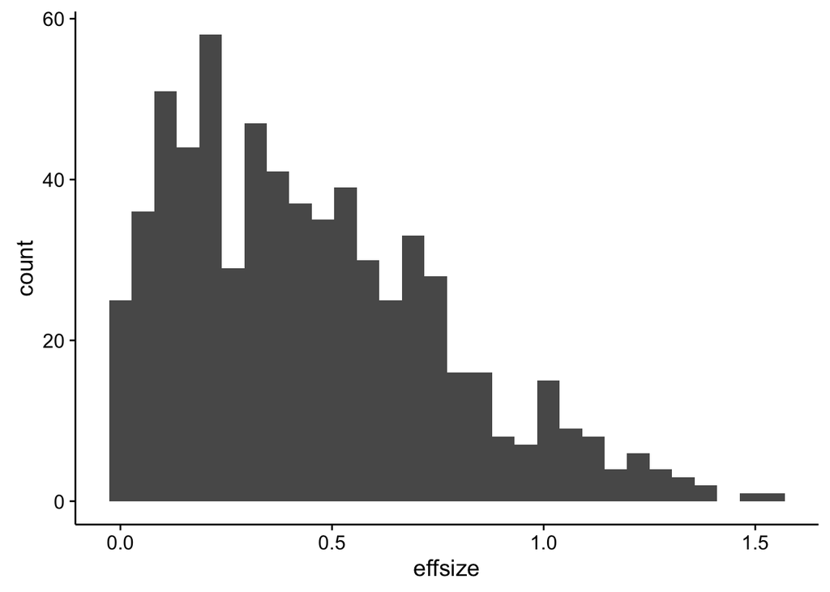

```r
> library(pwr)
> npmeans = rowMeans(ncounts[, 1:6])
> pmeans = rowMeans(ncounts[, 7:12])
> effsize = abs(npmeans - pmeans)/rowSds(ncounts)
> qplot(effsize) + geom_histogram()
```

```r
> pwr.t.test(d = median(effsize), sig.level = 0.05, power = 0.8, type = "two.sample")
```

```
     Two-sample t test power calculation

              n = 101.4189
              d = 0.3953159
      sig.level = 0.05
          power = 0.8
    alternative = two.sided

NOTE: n is number in *each* group
```

```r
> pwr.t.test(d = median(effsize) * 2, sig.level = 0.05, power = 0.8, type = "two.sample")
```

```
     Two-sample t test power calculation

              n = 26.10841
              d = 0.7906318
      sig.level = 0.05
          power = 0.8
    alternative = two.sided

NOTE: n is number in *each* group
```

The NanoString data is similar to RNA-seq data in terms of its characteristics. It is count based and can be well-fit by the negative binomial model. It has a similar mean-variance relationship as RNA-seq data which we show below. Here we estimate the dispersion of the NanoString data and then use that estimate to calculate sample sizes we would need to have 80% power to detect fold changes of at least 2x with a false positive rate of 0.05 in an experiment with 730 genes. We can see the estimated sample size agrees somewhat with that calculated by looking at the two sample t-test, we need somewhere around 20 samples per condition to be able to pull out differences between the samples.

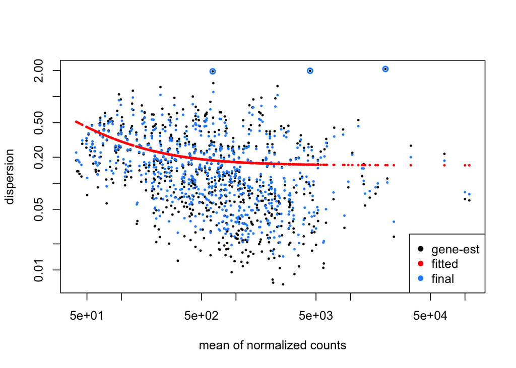

```r
> plotDispEsts(dds)
```

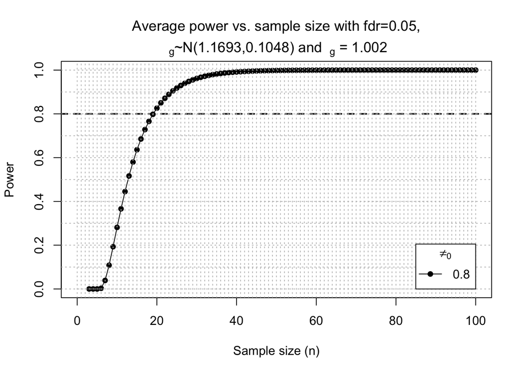

```r
> library(ssizeRNA)
> ss = ssizeRNA_single(nGenes = 730, pi0 = 0.8, m = 200, mu = 1500, disp = 0.3,
+     logfc = log(2), fdr = 0.05, power = 0.8, maxN = 100)
```

# Pathway analysis

Here we use GSEA to perform pathway analysis on the list of genes. We need to first pull out the Refseq IDs from the Nanostring IDs and convert those to Entrez IDs. Not all of the genes have Entrez IDs, however, we lose 22 genes through this conversion. I sorted the genes by signal to noise ratio, which I defined as the log2Fold change (the signal) divided by the log2Fold change standard error (the noise).

```r
> orgdb = "org.Hs.eg.db"
> biomart_dataset = "hsapiens_gene_ensembl"
> keggname = "hsa"
> library(dplyr)
> library(clusterProfiler)
> library(orgdb, character.only = TRUE)
> library(biomaRt)
```

```r
> converted = unlist(lapply(strsplit(res$rowname, "_", fixed = TRUE), "[", 4))
> converted = unlist(lapply(strsplit(converted, ".", fixed = TRUE), "[", 1))
> converted = paste0("NM_", converted)
> res$refseq_mrna = converted
```

```r
> mart = biomaRt::useMart(biomart = "ensembl", dataset = biomart_dataset)
> entrez = biomaRt::getBM(attributes = c("refseq_mrna", "entrezgene"), mart = mart)
> entrez$entrezgene = as.character(entrez$entrezgene)
> entrezsymbol = biomaRt::getBM(attributes = c("entrezgene", "hgnc_symbol"), mart = mart)
> entrezsymbol$entrezgene = as.character(entrezsymbol$entrezgene)
```

```r
> summarize_cp = function(res, comparison) {
+     summaries = data.frame()
+     for (ont in names(res)) {
+         ontsum = summary(res[[ont]])
+         ontsum$ont = ont
+         summaries = rbind(summaries, ontsum)
+     }
+     summaries$comparison = comparison
+     return(summaries)
+ }
>
> enrich_cp = function(res, comparison) {
+     res = res %>% data.frame() %>% tibble::rownames_to_column() %>% left_join(entrez,
+         by = refseq_mrna) %>% filter(!is.na(entrezgene))
+     universe = res$entrezgene
+     genes = subset(res, padj < 0.05)$entrezgene
+     mf = enrichGO(genes, universe = universe, OrgDb = orgdb, ont = "MF", pAdjustMethod = "BH",
+         qvalueCutoff = 1, pvalueCutoff = 1)
+     cc = enrichGO(genes, universe = universe, OrgDb = orgdb, ont = "CC", pAdjustMethod = "BH",
+         qvalueCutoff = 1, pvalueCutoff = 1)
+     bp = enrichGO(genes, universe = universe, OrgDb = orgdb, ont = "BP", pAdjustMethod = "BH",
+         qvalueCutoff = 1, pvalueCutoff = 1)
+     kg = enrichKEGG(gene = genes, universe = universe, organism = "mmu", pvalueCutoff = 1,
+         qvalueCutoff = 1, pAdjustMethod = "BH")
+     all = list(mf = mf, cc = cc, bp = bp, kg = kg)
+     all[["summary"]] = summarize_cp(all, comparison)
+     return(all)
+ }
```

```r
> gsea_cp = function(res, comparison) {
+     res = res %>% data.frame() %>% left_join(entrez, by = "refseq_mrna") %>%
+         filter(!is.na(entrezgene)) %>% filter(!is.na(log2FoldChange)) %>% filter(!is.na(lfcSE))
+     lfc = data.frame(res)[, "log2FoldChange"]
+     lfcse = data.frame(res)[, "lfcSE"]
+     genes = lfc/lfcse
+     names(genes) = res$entrezgene
+     genes = genes[order(genes, decreasing = TRUE)]
+     cc = gseGO(genes, ont = "CC", OrgDb = orgdb, nPerm = 500, pvalueCutoff = 1,
+         pAdjustMethod = "BH", verbose = TRUE)
+     mf = gseGO(genes, ont = "MF", OrgDb = orgdb, nPerm = 500, pvalueCutoff = 1,
+         pAdjustMethod = "BH", verbose = TRUE)
+     bp = gseGO(genes, ont = "bp", OrgDb = orgdb, nPerm = 500, pvalueCutoff = 1,
+         pAdjustMethod = "BH", verbose = TRUE)
+     # genes = data.frame(res)[, 'log2FoldChange'] names(genes) = res$entrezgene
+     # genes = genes[order(genes, decreasing=TRUE)] genes = genes[!is.na(genes)]
+     kg = gseKEGG(geneList = genes, organism = keggname, nPerm = 500, pvalueCutoff = 1,
+         verbose = TRUE)
+     if (orgdb == "org.Hs.eg.db") {
+         do = gseDO(geneList = genes, nPerm = 500, pvalueCutoff = 1, pAdjustMethod = "BH",
+             verbose = TRUE)
+         all = list(mf = mf, cc = cc, bp = bp, kg = kg, do = do)
+     } else {
+         all = list(mf = mf, cc = cc, bp = bp, kg = kg)
+     }
+     all[["summary"]] = summarize_cp(all, comparison)
+     return(all)
+ }
>
> convert_enriched_ids = function(res, entrezsymbol) {
+     res = res %>% mutate(geneID = strsplit(as.character(geneID), "/")) %>% tidyr::unnest(geneID) %>%
+         left_join(entrezsymbol, by = c(geneID = "entrezgene")) %>% group_by(ID,
+         Description, GeneRatio, BgRatio, pvalue, p.adjust, qvalue, Count, ont,
+         comparison) %>% summarise(geneID = paste(geneID, collapse = "/"), symbol = paste(mgi_symbol,
+         collapse = "/"))
+     return(res)
+ }
```

```r
> convert_core_ids = function(row) {
+     core_ids = data.frame(entrezgene = unlist(strsplit(row["core_enrichment"],
+         "/")[[1]])) %>% left_join(entrezsymbol, by = "entrezgene")
+     core_symbols = unique(core_ids$hgnc_symbol)
+     core_symbols = core_symbols[!is.na(core_symbols)]
+     names(core_symbols) = NULL
+     return(paste(core_symbols, collapse = "/"))
+ }
>
> convert_gsea_results = function(res) {
+     res$symbols = apply(res, 1, convert_core_ids)
+     return(res)
+ }
```

```r
> gsea_rs = gsea_cp(res, "progression status")
```

[output not shown]

```r
> gsea_summary = gsea_rs$summary %>% arrange(pvalue)
> gsea_summary = convert_gsea_results(gsea_summary)
> write_csv(gsea_summary, "gsea-progression.csv")
```

We don’t find any pathways or ontology terms differentially enriched via GSEA. I sorted the ontology/KEGG pathway terms by p-value and output a table of the results. The core_symbols are the genes that most strongly contributed to the pathway score, so the ones with the highest or lowest enrichment score depending on the direction of enrichment.